# Fire_department_research

David Leavenworth and Sean Malloy

2023-02-28

# Fire Department Calls for Service in San Francisco

Our work can be found in this repository here: https://github.com/seanjedi/fire_department_sf_research_project

## Loading our data sets and doing pre-processing

```r
## Script to get the dataset if we want the newest data
## Warning, this could take a very long time, possibly longer than 30 mins
# install.packages("RSocrata")
# library("RSocrata")
# fire_department <- read.socrata(
#  "https://data.sfgov.org/resource/nuek-vuh3.json",
# )
# write_csv(fire_department, "Fire_Department_Calls_for_Service.csv")
# You can get the CSV for the weather data for San Francisco using this link here: https://bulk.meteostat.net/v2/daily/72494.csv.gz
weatherData <- read_csv("72494.csv")
```

```
## ──────────────────────────────────────────────────────── Delimiter: "," dbl
## (10): ...2, 12.2, 23.3, 0.0, ...6, ...7, ...8, ...9, ...10, ...11 date (1):
## 1945-07-01
```

```r
firefighter <- read_csv("Fire_Department_Calls_for_Service.csv")
```

Get rid of fields with missing data and rename columns to be easier to work with (calls for service data set)

```r
names(firefighter) <- make.names(names(firefighter), unique = TRUE)
firefighter <- drop_na(firefighter)
```

Add column names and filter to the date range matching the calls for service data set (weather data set)

```r
names(weatherData) <- c("date", "tavg", "tmin", "tmax", "prcp", "snow", "wdir", "wssp", "wpgt", "pres", "tsun")
weatherData$date <- as.Date(weatherData$date)
weatherData <- filter(weatherData, weatherData$date >= as.Date("2001-01-01"))
```

Join our weather and fire department data together, and free some memory

```r
firefighter$date <- as.Date(firefighter$Call.Date, format = "%m/%d/%Y")
firefighter <- left_join(firefighter, weatherData, by = "date")
fire_department <- firefighter
rm(firefighter)
gc()
```

```
##             used  (Mb) gc trigger   (Mb)  max used   (Mb)
## Ncells  10366455 553.7   62480759 3336.9  40363737 2155.7
## Vcells 106097498 809.5  368178712 2809.0 459843893 3508.4
```

Need to fill in new weather data missing data with either 0 or na, so that we can anlyze it later

```r
fire_department <- fire_department %>%
  mutate_if(is.numeric, ~ replace_na(., 0))
fire_department[is.na(fire_department)] <- ""
```

Adding more fields for time data analysis

```r
fire_department <- mutate(fire_department, timetaken = as.numeric(as.POSIXct(Available.DtTm, format = "%m/%d/%Y %I:%M:%S %p") - as.POSIXct(Response.DtTm, format = "%m/%d/%Y %I:%M:%S %p")))

fire_department <- mutate(fire_department, arrivalTime = as.numeric(as.POSIXct(On.Scene.DtTm, format = "%m/%d/%Y %I:%M:%S %p") - as.POSIXct(Received.DtTm, format = "%m/%d/%Y %I:%M:%S %p")))

fire_department <- mutate(fire_department, hospitalTimeToArrive = as.numeric(as.POSIXct(Hospital.DtTm, format = "%m/%d/%Y %I:%M:%S %p") - as.POSIXct(Received.DtTm, format = "%m/%d/%Y %I:%M:%S %p")))

fire_department <- mutate(fire_department, transportTime = as.numeric(as.POSIXct(Hospital.DtTm, format = "%m/%d/%Y %I:%M:%S %p") - as.POSIXct(Transport.DtTm, format = "%m/%d/%Y %I:%M:%S %p")))

fire_department <- mutate(fire_department, responseTime = as.numeric(as.POSIXct(Response.DtTm, format = "%m/%d/%Y %I:%M:%S %p") - as.POSIXct(Received.DtTm, format = "%m/%d/%Y %I:%M:%S %p")))

fire_department <- mutate(fire_department, StationArea = as.numeric(Station.Area))
fire_department <- mutate(fire_department, Box = as.numeric(Box))
```

# Analysis of data within Fire Department dataset

```r
str(fire_department)
```

```
## tibble [848,540 × 52] (S3: tbl_df/tbl/data.frame)
##  $ Call.Number                         : chr [1:848540] "220111597" "211940163" "211940150" "211940174" ...
##  $ Unit.ID                             : chr [1:848540] "AM110" "73" "77" "62" ...
##  $ Incident.Number                     : chr [1:848540] "22005326" "21082786" "21082785" "21082787" ...
##  $ Call.Type                           : chr [1:848540] "Medical Incident" "Medical Incident" "Traffic Collision" "Medical Incident" ...
##  $ Call.Date                           : chr [1:848540] "01/11/2022" "07/13/2021" "07/13/2021" "07/13/2021" ...
##  $ Watch.Date                          : chr [1:848540] "01/11/2022" "07/12/2021" "07/12/2021" "07/12/2021" ...
##  $ Received.DtTm                       : chr [1:848540] "01/11/2022 12:59:13 PM" "07/13/2021 02:27:46 AM" "07/13/2021 02:14:37 AM" "07/13/2021 02:48:01 AM" ...
##  $ Entry.DtTm                          : chr [1:848540] "01/11/2022 01:02:48 PM" "07/13/2021 02:30:19 AM" "07/13/2021 02:14:37 AM" "07/13/2021 02:50:13 AM" ...
##  $ Dispatch.DtTm                       : chr [1:848540] "01/11/2022 01:03:30 PM" "07/13/2021 02:30:47 AM" "07/13/2021 02:14:54 AM" "07/13/2021 02:53:06 AM" ...
##  $ Response.DtTm                       : chr [1:848540] "01/11/2022 01:03:48 PM" "07/13/2021 02:30:59 AM" "07/13/2021 02:15:04 AM" "07/13/2021 02:54:19 AM" ...
##  $ On.Scene.DtTm                       : chr [1:848540] "01/11/2022 01:11:24 PM" "07/13/2021 02:42:16 AM" "07/13/2021 02:19:26 AM" "07/13/2021 03:08:39 AM" ...
##  $ Transport.DtTm                      : chr [1:848540] "01/11/2022 02:04:39 PM" "07/13/2021 02:51:27 AM" "07/13/2021 02:51:42 AM" "07/13/2021 03:29:15 AM" ...
##  $ Hospital.DtTm                       : chr [1:848540] "01/11/2022 02:52:05 PM" "07/13/2021 02:55:34 AM" "07/13/2021 02:57:45 AM" "07/13/2021 03:37:07 AM" ...
##  $ Call.Final.Disposition              : chr [1:848540] "Code 2 Transport" "Code 3 Transport" "Code 2 Transport" "Code 2 Transport" ...
```

[output cut: 38 more lines]

```r
summary(fire_department)
```

```
##  Call.Number          Unit.ID          Incident.Number     Call.Type
##  Length:848540      Length:848540      Length:848540      Length:848540
##  Class :character   Class :character   Class :character   Class :character
##  Mode  :character   Mode  :character   Mode  :character   Mode  :character
##
##
##
##
##   Call.Date          Watch.Date        Received.DtTm       Entry.DtTm
##  Length:848540      Length:848540      Length:848540      Length:848540
##  Class :character   Class :character   Class :character   Class :character
##  Mode  :character   Mode  :character   Mode  :character   Mode  :character
##
##
##
##
##  Dispatch.DtTm      Response.DtTm      On.Scene.DtTm      Transport.DtTm
##  Length:848540      Length:848540      Length:848540      Length:848540
##  Class :character   Class :character   Class :character   Class :character
##  Mode  :character   Mode  :character   Mode  :character   Mode  :character
##
##
##
##
##  Hospital.DtTm      Call.Final.Disposition Available.DtTm
##  Length:848540      Length:848540          Length:848540
##  Class :character   Class :character       Class :character
##  Mode  :character   Mode  :character       Mode  :character
##
##
##
##
##    Address              City           Zipcode.of.Incident  Battalion
##  Length:848540      Length:848540      Min.   :94102       Length:848540
##  Class :character   Class :character   1st Qu.:94103       Class :character
##  Mode  :character   Mode  :character   Median :94110       Mode  :character
##                                        Mean   :94113
##                                        3rd Qu.:94118
##                                        Max.   :94158
##
```

[output cut: 57 more lines]

```
##  Min.   :-7969118   Min.   :-6509947     Min.   :-6511193   Min.   :-7119.0
##  1st Qu.:     423   1st Qu.:    2101     1st Qu.:     531   1st Qu.:   98.0
##  Median :     610   Median :    2636     Median :     854   Median :  156.0
##  Mean   :     716   Mean   :    2746     Mean   :     938   Mean   :  212.4
##  3rd Qu.:     910   3rd Qu.:    3275     3rd Qu.:    1275   3rd Qu.:  232.0
##  Max.   :   44314   Max.   :   63612     Max.   :   44409   Max.   :42832.0
##  NA's   :3          NA's   :4            NA's   :3          NA's   :4
##   StationArea
##  Min.   : 1.00
##  1st Qu.: 3.00
##  Median :13.00
##  Mean   :17.58
##  3rd Qu.:32.00
##  Max.   :51.00
##  NA's   :2
```

21 categorical variables 15 Numerical variables 16 Date variables

> Numeric & Boolean Variables

| Variable | Description | Data Type |
| --- | --- | --- |
| ALS Unit | Does this unit includes ALS (Advance Life Support) resources? Is there a paramedic in this unit? | Boolean |
| Number of Alarms | Number of alarms associated with the incident. This is a number between 1 and 5 | Numeric |
| Unit sequence in call dispatch | A number that indicates the order this unit was assigned to this call | Numeric |
| Analysis.Neighborhoods | The neighborhood numeric value where the call originated | Numeric |
| tavg | The average air temperature in °C | Numeric |
| tmin | The minimum air temperature in °C | Numeric |
| tmax | The maximum air temperature in °C | Numeric |
| prcp | The daily precipitation total in mm Float | Numeric |
| snow | The maximum snow depth in mm Integer | Numeric |
| wdir | The average wind direction in degrees (°) | Numeric |
| wssp | The average wind speed in km/h | Numeric |
| wpgt | The peak wind gust in km/h | Numeric |
| pres | The average sea-level air pressure in hPa Float | Numeric |
| tsun | The daily sunshine total in minutes (m) Integer | Numeric |

> Text Variables

| Variable | Description | Data Type |
| --- | --- | --- |
| Address | Address of midblock point associated with incident (obfuscated address to protect caller privacy) | Text |
| Battalion | Emergency Response District (There are 9 Fire Emergency Response Districts) | Text |
| Box | Fire box associated with the address of the incident. A box is the smallest area used to divide the City. Each box is associated with a unique unit dispatch order. The City is divided into more than 2… | Text |
| Call Final Disposition | Disposition of the call (Code). For example TH2: Transport to Hospital - Code 2, FIR: Resolved by Fire Department | Text |
| Call Number | A unique 9-digit number assigned by the 911 Dispatch Center (DEM) to this call. These number are used for both Police and Fire calls | Text |
| Call Type | Type of call the incident falls into. See the list below | Text |
| Call Type Group | Call types are divided into four main groups: Fire, Alarm, Potential Life Threatening and Non Life Threatening | Text |
| City | City of incident | Text |
| Final Priority | Final call priority (Code 2: Non-Emergency or Code 3:Emergency) | Text |
| Fire Prevention District | Bureau of Fire Prevention District associated with this address | Text |
| Incident Number | A unique 8-digit number assigned by DEM to this Fire incident | Text |
| Location | Latitude and longitude of address obfuscated either to the midblock, intersection or call box | Coordinates |
| Neighborhood District | Neighborhood District associated with this address, boundaries available here: https://data.sfgov.org/d/p5b7-5n3h | Text |
| Original Priority | Initial call priority (Code 2: Non-Emergency or Code 3:Emergency) | Text |
| Priority | Call priority (Code 2: Non-Emergency or Code 3:Emergency) | Text |
| RowID | Unique identifier used for managing data updates. It is the concatenation of Call Number and Unit ID separated by a dash | Text |
| Station Area | Fire Station First Response Area associated with the address of the incident | Text |
| Supervisor District | Supervisor District associated with this address | Text |
| Unit ID | Unit Identifier. For example E01 for Engine 1 or T01 for Truck 1 | Text |
| Unit Type | Unit type | Text |
| Zipcode of Incident | Zipcode of incident | Text |

> Date & Time Variables

| Variable | Description | Data Type |
| --- | --- | --- |
| Available DtTm | Date and time this unit is not longer assigned to this call and it is available for another dispatch | Date & Time |
| AVL Validated On Scene DtTm | Updated date and time the unit arrived on scene based on existing unit AVL coordinates | Date & Time |
| Call Date | Date the call is received at the 911 Dispatch Center. Used for reporting purposes | Date & Time |
| Dispatch DtTm | Date and time the 911 operator dispatches this unit to the call | Date & Time |
| Entry DtTm | Date and time the 911 operator submits the entry of the initial call information into the CAD system | Date & Time |
| Hospital DtTm | If this unit is an ambulance, date and time the unit arrives to the hospital | Date & Time |
| On Scene DtTm | Date and time the unit records arriving to the location of the incident | Date & Time |
| Received DtTm | Date and time of call is received at the 911 Dispatch Center | Date & Time |
| Response DtTm | Date and time this unit acknowledges the dispatch and records that the unit is en route to the location of the call | Date & Time |
| Transport DtTm | If this unit is an ambulance, date and time the unit begins the transport unit arrives to hospital | Date & Time |
| Watch Date | Watch date when the call is received. Watch date starts at 0800 each morning and ends at 0800 the next day | Date & Time |

> Call Types - categories
- Administrative
- Aircraft Emergency
- Alarms
- Assist Police
- Citizen Assist / Service Call
- Confined Space / Structure Collapse
- Electrical Hazard
- Elevator / Escalator Rescue
- Explosion
- Extrication / Entrapped (Machinery, Vehicle)
- Fuel Spill
- Gas Leak (Natural and LP Gases)
- HazMat
- High Angle Rescue
- Industrial Accidents
- Lightning Strike (Investigation)
- Marine Fire
- Medical Incident
- Mutual Aid / Assist Outside Agency
- Odor (Strange / Unknown)
- Oil Spill
- Other
- Outside Fire
- Smoke Investigation (Outside)
- Structure Fire
- Suspicious Package
- Traffic Collision
- Train / Rail Fire
- Train / Rail Incident
- Transfer
- Vehicle Fire
- Water Rescue
- Watercraft in Distress

> New Fields

[output not shown]

## Exploratory Data Analysis

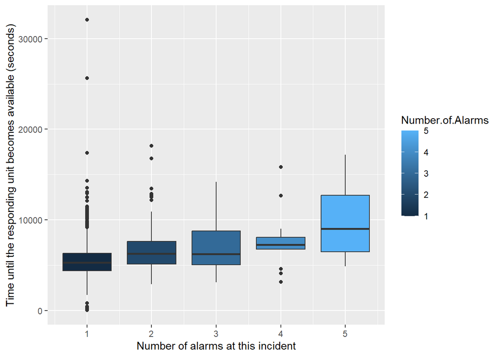

```r
fire_department %>%
  filter(Call.Type.Group == "Fire") %>%
  mutate(timetaken = as.numeric(as.POSIXct(Available.DtTm, format = "%m/%d/%Y %I:%M:%S %p") - as.POSIXct(Response.DtTm, format = "%m/%d/%Y %I:%M:%S %p"))) %>%
  ggplot(aes(Number.of.Alarms, timetaken, group = Number.of.Alarms, fill = Number.of.Alarms)) +
  geom_boxplot() +
  labs(x = "Number of alarms at this incident", y = "Time until the responding unit becomes available (seconds)")
```

It looks like as the number of alarms increases the median time for a unit to become available again increases as well. The number of alarms is a categorical variable because it can only take on a value from 1-5.

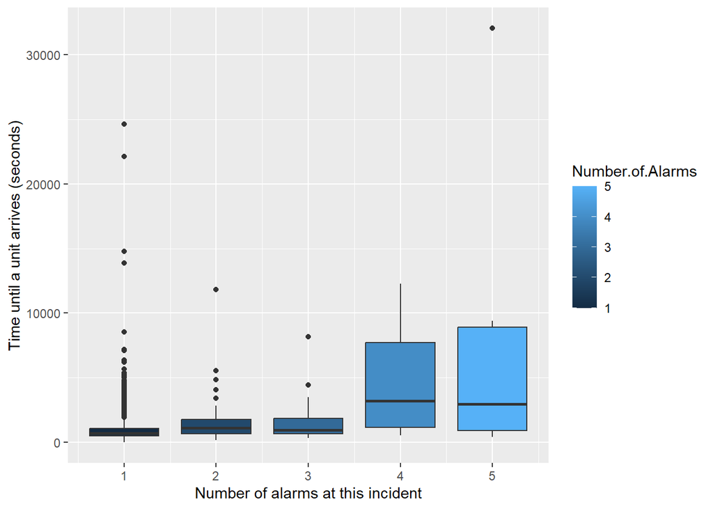

```r
fire_department %>%
  filter(Call.Type.Group == "Fire") %>%
  ggplot(aes(Number.of.Alarms, arrivalTime, group = Number.of.Alarms, fill = Number.of.Alarms)) +
  geom_boxplot() +
  labs(x = "Number of alarms at this incident", y = "Time until a unit arrives (seconds)")
```

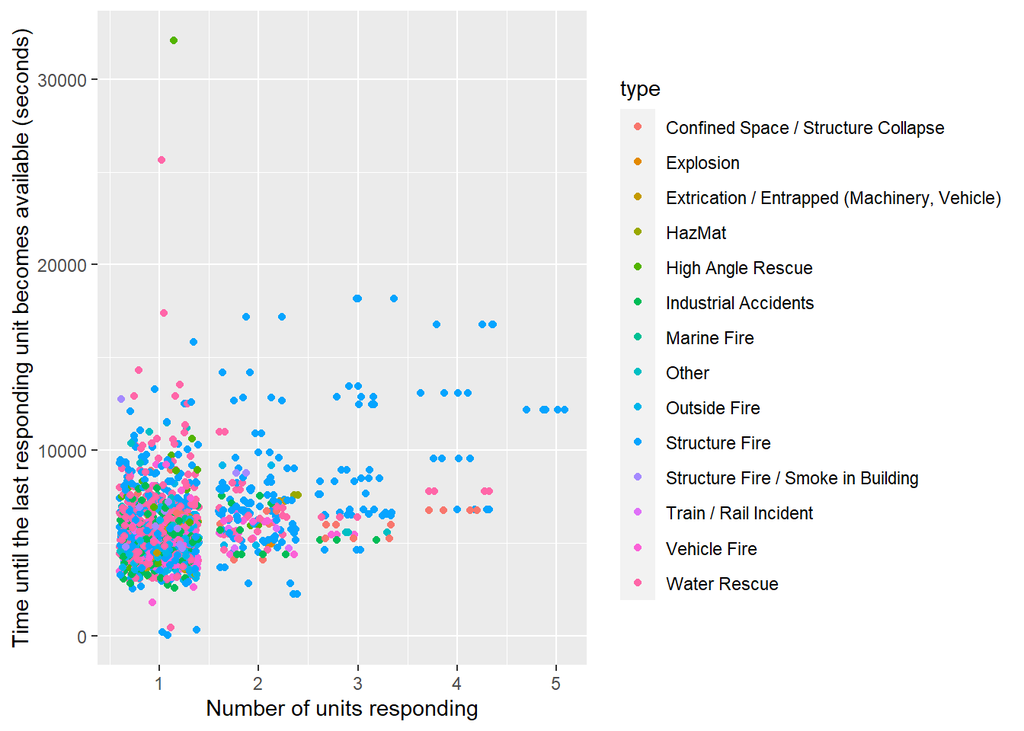

```r
fire_department %>%
  filter(Call.Type.Group == "Fire") %>%
  group_by(Incident.Number) %>%
  summarise(count = n(), callfinishtime = max(timetaken), type = Call.Type) %>%
  ggplot(aes(count, callfinishtime, color = type)) +
  geom_jitter() +
  labs(x = "Number of units responding", y = "Time until the last responding unit becomes available (seconds)")
```

It seems that the number of units responding to a call causes the last unit to become available again the longest, suggesting that having less units respond to a call would make all the units available again sooner. We can see that this might be dependent on what type of call it is, with a structure fire causing more units to be present and stay longer.

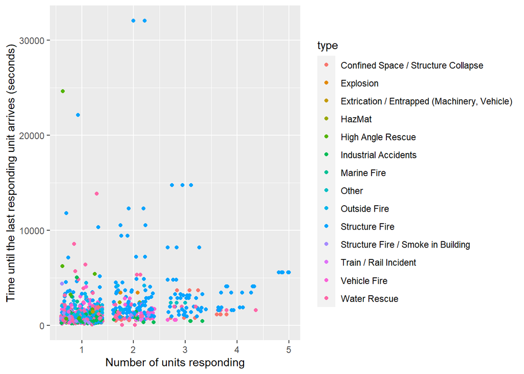

```r
fire_department %>%
  filter(Call.Type.Group == "Fire") %>%
  group_by(Incident.Number) %>%
  summarise(count = n(), callfinishtime = max(arrivalTime), type = Call.Type) %>%
  ggplot(aes(count, callfinishtime, color = type)) +
  geom_jitter() +
  labs(x = "Number of units responding", y = "Time until the last responding unit arrives (seconds)")
```

We can see that the number of units that are called would also increase the time that the last unit would arrive, with this also being higher on cases with a structural fire.

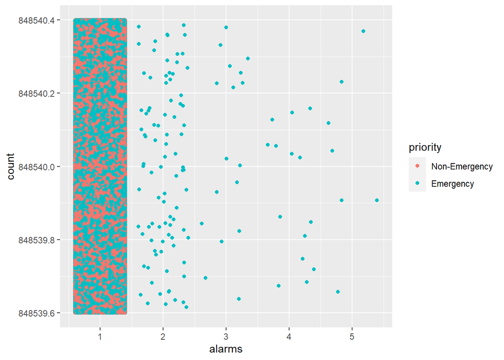

```r
fire_department %>%
  mutate(category = cut(Final.Priority, 2, labels = c("Non-Emergency", "Emergency"))) %>%
  summarise(count = n(), alarms = Number.of.Alarms, priority = category) %>%
  ggplot(aes(alarms, count, color = priority)) +
  geom_jitter()
```

This shows us that all non-emergency calls will only have 1 alarm, however there is not a good method of differentiating what counts as an emergency call or a non-emergency call with the number of alarms in this example.

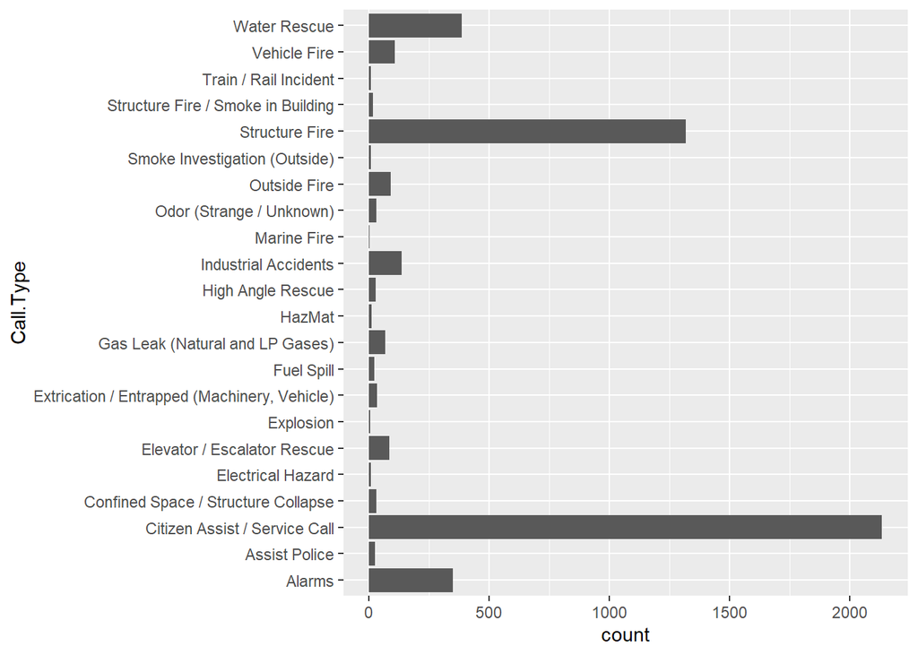

```r
fire_department %>%
  filter(Call.Type != "Medical Incident" & Call.Type != "Traffic Collision" & Call.Type != "Other") %>%
  group_by(Call.Type) %>%
  summarize(count = n()) %>%
  ggplot(aes(count, Call.Type)) +
  geom_bar(stat = "identity")
```

In this plot we can see that after filtering incidents with the Other, Traffic Collision, and Medical Incident types the most common incident types are Citizen Assists and Structure fires.

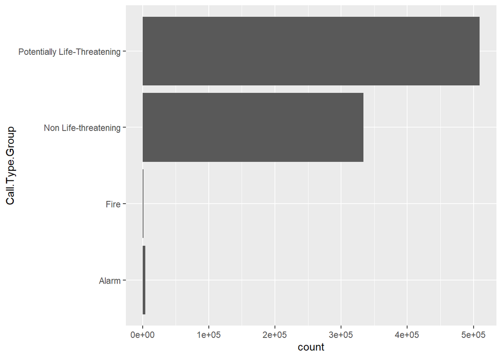

```r
fire_department$Call.Type.Group[fire_department$Call.Type.Group == ""] <- "Other"
fire_department %>%
  group_by(Call.Type.Group) %>%
  summarize(count = n()) %>%
  ggplot(aes(count, Call.Type.Group)) +
  geom_bar(stat = "identity")
```

In the above plot we can see that potentially life threatening incidents are the most common, while there is a very small amount of fire and alarm incidents.

## Statistical Analysis

```r
fire_department <- drop_na(fire_department)
fire_department %>%
  select("Number.of.Alarms", "responseTime", "StationArea", "Zipcode.of.Incident", "Unit.sequence.in.call.dispatch", "timetaken", "arrivalTime", "hospitalTimeToArrive", "transportTime", "tavg", "tmin", "tmax", "prcp", "wdir", "wssp", "pres") %>%
  cor()
```

```
##                                Number.of.Alarms  responseTime   StationArea
## Number.of.Alarms                   1.0000000000  0.0716992897  0.0029300428
## responseTime                       0.0716992897  1.0000000000  0.0097439048
## StationArea                        0.0029300428  0.0097439048  1.0000000000
## Zipcode.of.Incident                0.0051887780  0.0128953468  0.3001668841
## Unit.sequence.in.call.dispatch     0.2580517358  0.1646384350  0.0771555588
## timetaken                          0.0244547816  0.0492375187  0.1122122652
## arrivalTime                        0.0020530643  0.0286851504  0.0020312087
## hospitalTimeToArrive               0.0062432498  0.0486261653  0.0161591672
## transportTime                      0.0004342475  0.0024492355  0.0100187986
## tavg                               0.0009670615  0.0175614766 -0.0030784412
## tmin                               0.0005870784  0.0167778756 -0.0039249406
## tmax                               0.0021118705  0.0179831801 -0.0007329236
## prcp                               0.0013636504  0.0089786638 -0.0017056628
## wdir                              -0.0013543454 -0.0183641308  0.0033860151
## wssp                               0.0004997318 -0.0040385514 -0.0029478600
## pres                               0.0009576254 -0.0006087627 -0.0003454602
##                                Zipcode.of.Incident
## Number.of.Alarms                      0.0051887780
## responseTime                          0.0128953468
## StationArea                           0.3001668841
## Zipcode.of.Incident                   1.0000000000
## Unit.sequence.in.call.dispatch        0.1103253175
## timetaken                             0.1577295859
## arrivalTime                           0.0047708331
## hospitalTimeToArrive                  0.0235738048
## transportTime                         0.0133697823
## tavg                                 -0.0018903660
## tmin                                 -0.0034116311
## tmax                                  0.0012516488
## prcp                                 -0.0038735024
## wdir                                  0.0038581345
## wssp                                 -0.0027273333
## pres                                  0.0009058451
##                                Unit.sequence.in.call.dispatch   timetaken
## Number.of.Alarms                                  0.258051736  0.02445478
## responseTime                                      0.164638435  0.04923752
## StationArea                                       0.077155559  0.11221227
## Zipcode.of.Incident                               0.110325318  0.15772959
## Unit.sequence.in.call.dispatch                    1.000000000  0.01309560
```

[output cut: 64 more lines]

```
## responseTime                   -6.087627e-04
## StationArea                    -3.454602e-04
## Zipcode.of.Incident             9.058451e-04
## Unit.sequence.in.call.dispatch -3.386756e-03
## timetaken                       1.676978e-02
## arrivalTime                    -6.681114e-05
## hospitalTimeToArrive           -2.270437e-04
## transportTime                  -8.080551e-04
## tavg                            2.671224e-02
## tmin                           -3.430931e-02
## tmax                            2.402254e-02
## prcp                           -9.860083e-02
## wdir                            9.737812e-02
## wssp                           -7.588030e-03
## pres                            1.000000e+00
```

```r
# fire_department %>%
#  select("Number.of.Alarms", "responseTime", "StationArea", "Zipcode.of.Incident", "Unit.sequence.in.call.dispatch", #"timetaken", "arrivalTime", "hospitalTimeToArrive", "transportTime") %>%
#  pairs()
```

```r
fire_department %>%
  select("Number.of.Alarms", "responseTime", "StationArea", "Zipcode.of.Incident", "Unit.sequence.in.call.dispatch", "timetaken", "arrivalTime", "hospitalTimeToArrive", "transportTime", "tavg", "tmin", "tmax", "prcp", "wdir", "wssp", "pres") %>%
  cor(method = "spearman")
```

```
##                                Number.of.Alarms responseTime   StationArea
## Number.of.Alarms                   1.000000e+00  0.009524412  0.0044528080
## responseTime                       9.524412e-03  1.000000000  0.0089710611
## StationArea                        4.452808e-03  0.008971061  1.0000000000
## Zipcode.of.Incident                6.952717e-03  0.015035523  0.4210150889
## Unit.sequence.in.call.dispatch     2.356161e-02  0.029513243  0.0854239786
## timetaken                          1.336564e-02  0.044521672  0.1288241238
## arrivalTime                        1.054666e-02  0.460005882  0.0866620063
## hospitalTimeToArrive               1.268794e-02  0.261580999  0.1391873077
## transportTime                      9.997045e-04  0.061619549  0.1303637409
## tavg                              -3.002387e-06  0.008965415 -0.0035477509
## tmin                              -1.646367e-04  0.010692790 -0.0042003642
## tmax                               1.368796e-03  0.008345781 -0.0007636616
## prcp                               3.046120e-03 -0.006250742 -0.0031872712
## wdir                              -1.173951e-03 -0.050873816  0.0088858559
## wssp                               7.840525e-04 -0.003669684 -0.0028749354
## pres                               6.289705e-04 -0.006290328  0.0026494249
##                                Zipcode.of.Incident
## Number.of.Alarms                      0.0069527168
## responseTime                          0.0150355233
## StationArea                           0.4210150889
## Zipcode.of.Incident                   1.0000000000
## Unit.sequence.in.call.dispatch        0.1376361485
## timetaken                             0.1669825130
## arrivalTime                           0.1243323543
## hospitalTimeToArrive                  0.1888917871
## transportTime                         0.1594270654
## tavg                                 -0.0036952294
## tmin                                 -0.0045023887
## tmax                                 -0.0007839527
## prcp                                 -0.0043424002
## wdir                                  0.0007695685
## wssp                                 -0.0042860174
## pres                                  0.0049093514
##                                Unit.sequence.in.call.dispatch    timetaken
## Number.of.Alarms                                  0.023561611  0.013365640
## responseTime                                      0.029513243  0.044521672
## StationArea                                       0.085423979  0.128824124
## Zipcode.of.Incident                               0.137636148  0.166982513
## Unit.sequence.in.call.dispatch                    1.000000000 -0.004215821
```

[output cut: 64 more lines]

```
## responseTime                   -0.0062903276
## StationArea                     0.0026494249
## Zipcode.of.Incident             0.0049093514
## Unit.sequence.in.call.dispatch -0.0019441833
## timetaken                       0.0144901819
## arrivalTime                    -0.0041085378
## hospitalTimeToArrive            0.0014640082
## transportTime                  -0.0040875965
## tavg                           -0.4687648396
## tmin                           -0.4971242330
## tmax                           -0.3749694464
## prcp                           -0.1303348794
## wdir                           -0.0974777018
## wssp                           -0.3704219202
## pres                            1.0000000000
```

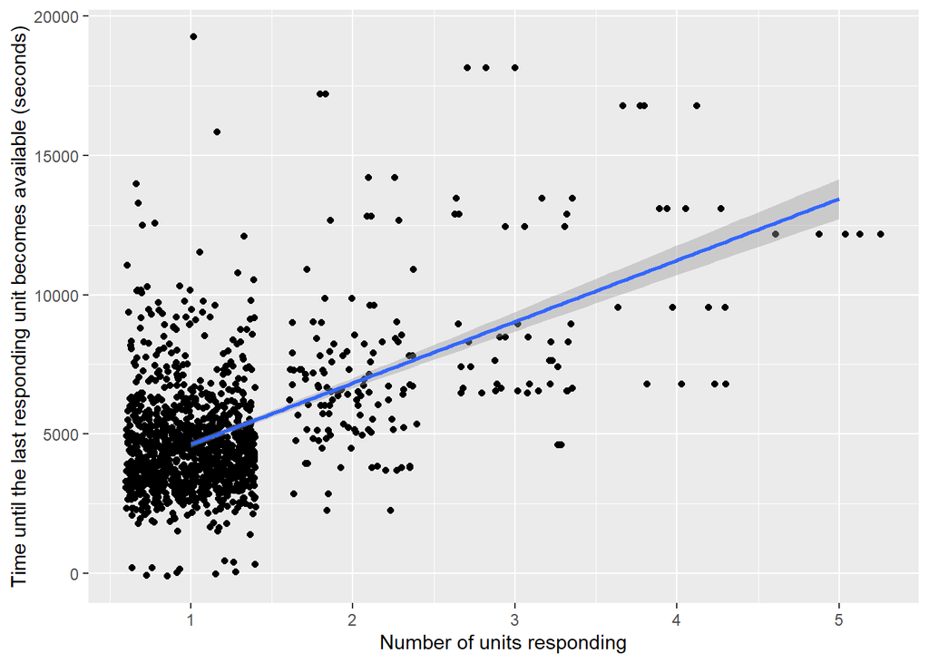

```r
fire_department %>%
  filter(Call.Type == "Structure Fire") %>%
  group_by(Incident.Number) %>%
  summarise(count = n(), callfinishtime = max(timetaken), type = Call.Type) %>%
  ggplot(aes(count, callfinishtime)) +
  geom_jitter() +
  geom_smooth(method = "lm") +
  labs(x = "Number of units responding", y = "Time until the last responding unit becomes available (seconds)")
```

```r
toTest <- filter(fire_department, Call.Type == "Structure Fire")
toTest <- group_by(toTest, Incident.Number)
toTest <- summarise(toTest, count = n(), callfinishtime = max(timetaken))
myLm <- lm(toTest$callfinishtime ~ toTest$count)
summary(myLm)
```

```
##
## Call:
## lm(formula = toTest$callfinishtime ~ toTest$count)
##
## Residuals:
##     Min      1Q  Median      3Q     Max
## -4733.5 -1222.5  -257.5   728.8 14639.5
##
## Coefficients:
##              Estimate Std. Error t value Pr(>|t|)
## (Intercept)    2390.9      174.1   13.73   <2e-16 ***
## toTest$count   2231.6      152.1   14.68   <2e-16 ***
## ---
## Signif. codes:  0 '***' 0.001 '**' 0.01 '*' 0.05 '.' 0.1 ' ' 1
##
## Residual standard error: 1930 on 1212 degrees of freedom
## Multiple R-squared:  0.1509, Adjusted R-squared:  0.1502
## F-statistic: 215.3 on 1 and 1212 DF,  p-value: < 2.2e-16
```

With a P-value significantly below 0.05 we can conclude that there is at least some correlation between the time it takes for an incident to be resolved and the number of units responding. However, with an R-squared value of 0.15, only 15% of variation in the call finish time can be explained by the number of units at this incident. This makes sense considering the number of units is likely a function of how severe the incident is, or other factors specific to individual incidents. In other words, there is likely some other variable which predicts both how many units are responding and how long an incident takes to resolve.

```r
smaller_data <- filter(fire_department, Call.Type.Group == "Fire")
cor.test(smaller_data$timetaken, smaller_data$Number.of.Alarms, method = "spearman")
```

```
##
##  Spearman's rank correlation rho
##
## data:  smaller_data$timetaken and smaller_data$Number.of.Alarms
## S = 279821957, p-value = 1.017e-12
## alternative hypothesis: true rho is not equal to 0
## sample estimates:
##       rho
## 0.1975432
```

In the above tests we can see that the time taken for individual units to become available is very lightly correlated with the number of alarms at a fire incident. Note that we used Spearman’s correlation due to the presence of outliers in our data.

```r
emerg <- filter(fire_department, Priority == 3)
non_emerg <- filter(fire_department, Priority == 2)

t.test(emerg$timetaken, non_emerg$timetaken)
```

```
##
##  Welch Two Sample t-test
##
## data:  emerg$timetaken and non_emerg$timetaken
## t = -90.424, df = 792418, p-value < 2.2e-16
## alternative hypothesis: true difference in means is not equal to 0
## 95 percent confidence interval:
##  -258.5243 -247.5549
## sample estimates:
## mean of x mean of y
##  4561.463  4814.503
```

In the above tests we can see that the mean time taken between emergency and non-emergency incidents for individual units is in fact different. Looking at the confidence interval (and the values of the means) we can see that the time taken for individual units to become available again in emergency incidents is lower than in non-emergency incidents.

```r
life_threataning <- filter(fire_department, Call.Type.Group == "Potentially Life-Threatening")
non_life_threataning <- filter(fire_department, Call.Type.Group == "Non Life-threatening")

t.test(life_threataning$timetaken, non_life_threataning$timetaken)
```

```
##
##  Welch Two Sample t-test
##
## data:  life_threataning$timetaken and non_life_threataning$timetaken
## t = -76.449, df = 667991, p-value < 2.2e-16
## alternative hypothesis: true difference in means is not equal to 0
## 95 percent confidence interval:
##  -223.4455 -212.2746
## sample estimates:
## mean of x mean of y
##  4584.834  4802.694
```

In the above tests we can see that the mean time taken for life-threatening events is lower than the mean time taken for non life-threatening events. This would make sense considering the time taken for life threatening events would mean life or death for the people who were in danger.

### Precipitation correlation analysis

```r
raining <- filter(fire_department, prcp > 1)
not_raining <- filter(fire_department, prcp <= 1)
t.test(raining$timetaken, not_raining$timetaken)
```

```
##
##  Welch Two Sample t-test
##
## data:  raining$timetaken and not_raining$timetaken
## t = 14.065, df = 120921, p-value < 2.2e-16
## alternative hypothesis: true difference in means is not equal to 0
## 95 percent confidence interval:
##  53.23447 70.47357
## sample estimates:
## mean of x mean of y
##  4728.708  4666.854
```

```r
cor.test(fire_department$timetaken, fire_department$prcp, method = "spearman")
```

```
##
##  Spearman's rank correlation rho
##
## data:  fire_department$timetaken and fire_department$prcp
## S = 1.0021e+17, p-value < 2.2e-16
## alternative hypothesis: true rho is not equal to 0
## sample estimates:
##       rho
## 0.0158795
```

```r
myLm <- lm(fire_department$prcp ~ fire_department$timetaken)
summary(myLm)
```

```
##
## Call:
## lm(formula = fire_department$prcp ~ fire_department$timetaken)
##
## Residuals:
##     Min      1Q  Median      3Q     Max
##  -7.093  -1.314  -1.228  -1.135 101.164
##
## Coefficients:
##                            Estimate Std. Error t value Pr(>|t|)
## (Intercept)               8.082e-01  2.310e-02   34.99   <2e-16 ***
## fire_department$timetaken 9.776e-05  4.770e-06   20.49   <2e-16 ***
## ---
## Signif. codes:  0 '***' 0.001 '**' 0.01 '*' 0.05 '.' 0.1 ' ' 1
##
## Residual standard error: 5.558 on 848529 degrees of freedom
## Multiple R-squared:  0.0004947,  Adjusted R-squared:  0.0004936
## F-statistic:   420 on 1 and 848529 DF,  p-value: < 2.2e-16
```

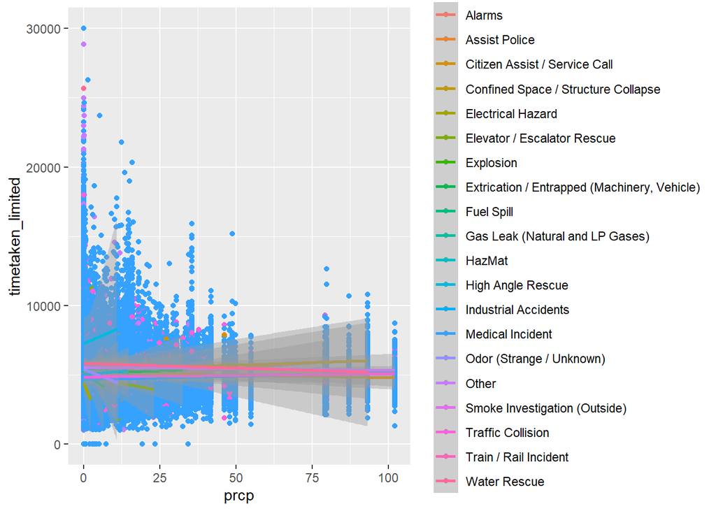

```r
fire_data <- filter(fire_department, !grepl("Fire", fire_department$Call.Type))
fire_data %>%
  mutate(timetaken_limited = case_when(timetaken > 30000 ~ 30000, timetaken <= 0 ~ 0, timetaken >= 1000 ~ timetaken)) %>%
  drop_na() %>%
  ggplot(aes(prcp, timetaken_limited, color = Call.Type)) +
  geom_point() +
  geom_smooth(method = "lm")
```

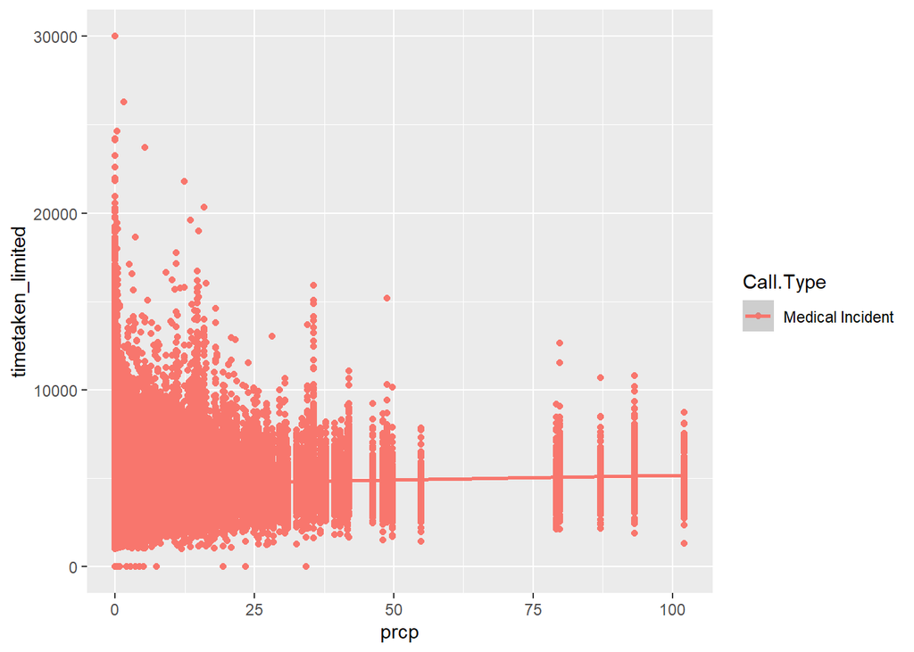

```r
fire_data <- filter(fire_department, grepl("Medical", fire_department$Call.Type))
fire_data %>%
  mutate(timetaken_limited = case_when(timetaken > 30000 ~ 30000, timetaken <= 0 ~ 0, timetaken >= 1000 ~ timetaken)) %>%
  drop_na() %>%
  ggplot(aes(prcp, timetaken_limited, color = Call.Type)) +
  geom_point() +
  geom_smooth(method = "lm")
```

With the statistical analysis above, we had found that precipitation and the time taken before a unit is avaialbe again has a very low p-value in both correlation and with t-testing, which would indicate to us that the time taken increases with precipitation, however when looking at the graphs and the given r-squared value, even if there is a light correlation between these two, we can see that there is more that needs to be considered, and that precipitation is a very small factor in determining how long a unit will take at the scene of an incident.

### Precipitation correlation analysis

```r
raining <- filter(fire_department, prcp > 1)
not_raining <- filter(fire_department, prcp <= 1)
t.test(raining$arrivalTime, not_raining$arrivalTime)
```

```
##
##  Welch Two Sample t-test
##
## data:  raining$arrivalTime and not_raining$arrivalTime
## t = 1.6267, df = 770124, p-value = 0.1038
## alternative hypothesis: true difference in means is not equal to 0
## 95 percent confidence interval:
##  -5.014153 53.970098
## sample estimates:
## mean of x mean of y
##  737.7344  713.2564
```

```r
cor.test(fire_department$arrivalTime, fire_department$prcp, method = "spearman")
```

```
##
##  Spearman's rank correlation rho
##
## data:  fire_department$arrivalTime and fire_department$prcp
## S = 1.0175e+17, p-value = 0.4973
## alternative hypothesis: true rho is not equal to 0
## sample estimates:
##          rho
## 0.0007369121
```

```r
myLm <- lm(fire_department$prcp ~ fire_department$arrivalTime)
summary(myLm)
```

```
##
## Call:
## lm(formula = fire_department$prcp ~ fire_department$arrivalTime)
##
## Residuals:
##     Min      1Q  Median      3Q     Max
##  -1.283  -1.265  -1.265  -1.265 100.835
##
## Coefficients:
##                              Estimate Std. Error t value Pr(>|t|)
## (Intercept)                 1.265e+00  6.046e-03 209.203   <2e-16 ***
## fire_department$arrivalTime 4.067e-07  4.940e-07   0.823     0.41
## ---
## Signif. codes:  0 '***' 0.001 '**' 0.01 '*' 0.05 '.' 0.1 ' ' 1
##
## Residual standard error: 5.56 on 848529 degrees of freedom
## Multiple R-squared:  7.989e-07,  Adjusted R-squared:  -3.796e-07
## F-statistic: 0.6779 on 1 and 848529 DF,  p-value: 0.4103
```

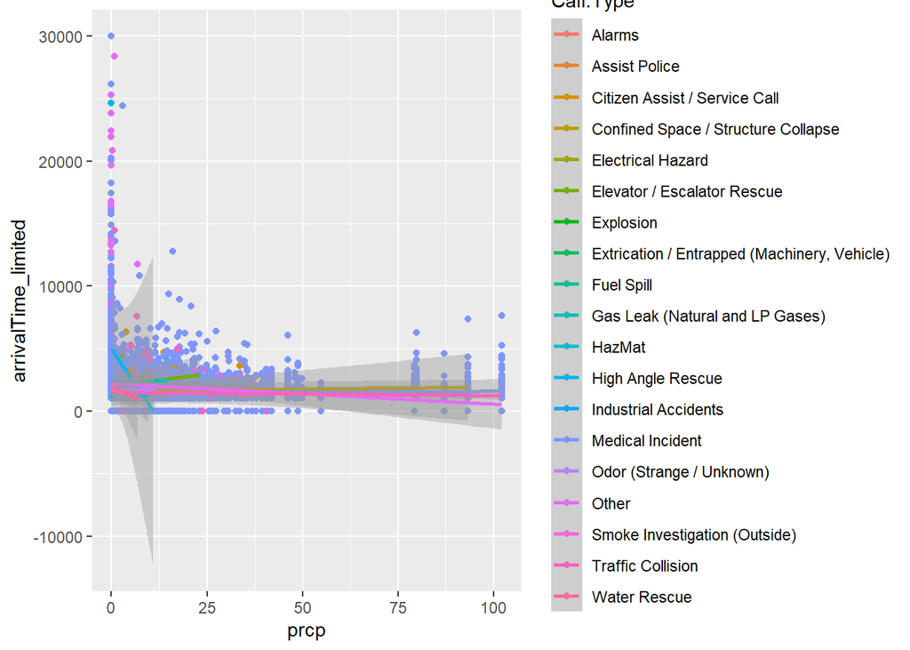

```r
fire_data <- filter(fire_department, !grepl("Fire", fire_department$Call.Type))
fire_data %>%
  mutate(arrivalTime_limited = case_when(arrivalTime > 30000 ~ 30000, arrivalTime <= 0 ~ 0, arrivalTime >= 1000 ~ arrivalTime)) %>%
  drop_na() %>%
  ggplot(aes(prcp, arrivalTime_limited, color = Call.Type)) +
  geom_point() +
  geom_smooth(method = "lm")
```

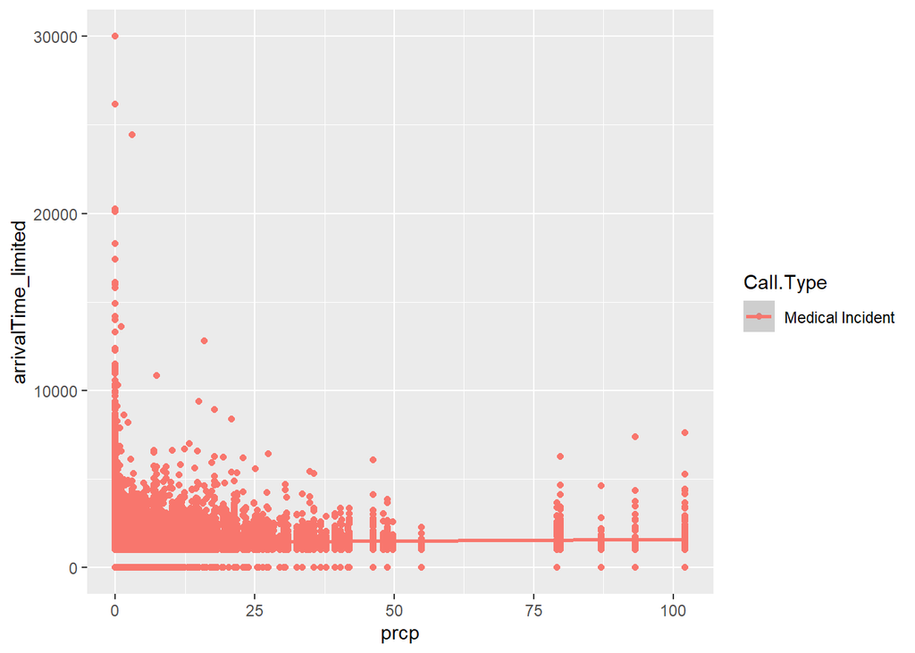

```r
fire_data <- filter(fire_department, grepl("Medical", fire_department$Call.Type))
fire_data %>%
  mutate(arrivalTime_limited = case_when(arrivalTime > 30000 ~ 30000, arrivalTime <= 0 ~ 0, arrivalTime >= 1000 ~ arrivalTime)) %>%
  drop_na() %>%
  ggplot(aes(prcp, arrivalTime_limited, color = Call.Type)) +
  geom_point() +
  geom_smooth(method = "lm")
```

With the statistical analysis we have with the precipitation and arrival time, which is the amount of time that it takes a unit to arrive at a scene, we can determine that our hypothesis is incorrect, since the P-Value and the confidence interval ranges between 0.